# Resumen datos generales

Jesús Escudero

5/2/2020

## Introducción

Los [microdatos](https://www.ine.es/dyngs/INEbase/es/operacion.htm?c=Estadistica_C&cid=1254736176918&menu=resultados&secc=1254736030639&idp=1254735976595) corresponden a todos los trimestres de la Encuesta de Población ACtiva, publicada por el INE, entre 2005 y 2019, ambos años inclusive. La forma de unir, combinar y filtrar los microdatos para tener sólo los microdatos de encuestas correspondientes a los ocupados se encuentra detallados en los scripts **01_importar_combinar_datos.R** y **02_filtrar_datos_ocupados.R** alojados en la carpeta **scripts/scripts/**.

Por tanto, este informe-resumen se centra en los microdatos correspondientes a los ocupados de la EPA de 2005 a 2019 a partir del archivo **datos/output/ocupados_con_flujos.csv**.

Hay que tener en cuenta que el número de ocupados que publica la EPA están calculados en base a la **provincia donde está ubicada la vivienda**, no a la provincia donde está ubicado el puesto de trabajo.

```r
# Cargar librerías
library(tidyverse)
library(lubridate)
library(DT)
library(ggplot2)

# Set working directory original
setwd("C:/Users/jescudero/Desktop/proyectos_r/Grandes Proyectos/microdatos_epa/")

# Importar datos
datos <- read_csv("datos/output/ocupados_con_flujos_trimestres.csv")
```

## % trabajadores que viven en otra provincia de la que trabajan

El número y porcentaje de trabajadores que viven en un provincia diferente de la que trabajan han tocado techo en 2019, con una media anual de **628.500 trabajadores** (sobre un total de 19,78 millones), situándose en el 3,18%. El repunte ha sido significativo a partir de 2015.

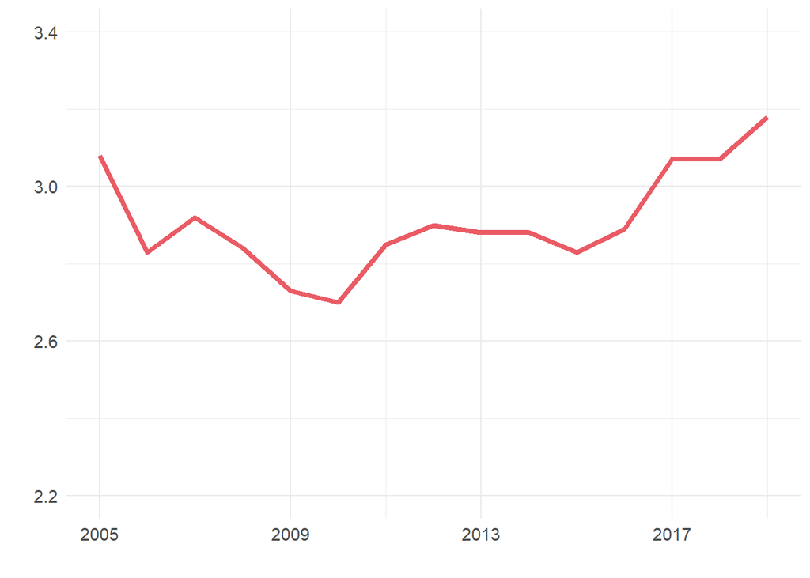

*Las siguientes tablas son descargables a través de los botones que aparecen en su encabezado*

## Provincias (en función del lugar de trabajo) con mayor porcentaje de trabajadores que viven en otras provincias

|  | provincia_trabajo | 2005 | 2006 | 2007 | 2008 | 2009 | 2010 | 2011 | 2012 | 2013 | 2014 | 2015 | 2016 | 2017 | 2018 | 2019 |
| --- | --- | --- | --- | --- | --- | --- | --- | --- | --- | --- | --- | --- | --- | --- | --- | --- |
| 1 | Albacete | 2.87 | 3.44 | 2.77 | 2.62 | 2.55 | 2.89 | 2.28 | 3.48 | 4.95 | 2.81 | 3.5 | 3.36 | 3.26 | 4 | 5.44 |
| 2 | Alicante/Alacant | 2.72 | 2.28 | 2.64 | 1.95 | 2.08 | 1.81 | 1.71 | 2.19 | 1.87 | 1.71 | 1.99 | 1.78 | 2.1 | 1.87 | 1.86 |
| 3 | Almería | 2.74 | 2.39 | 2.09 | 2.55 | 2.85 | 1 | 1.25 | 1.05 | 1.23 | 1.49 | 2.35 | 1.94 | 2.08 | 2.64 | 2.09 |
| 4 | Araba/Álava | 13.19 | 11.92 | 11.97 | 13.47 | 10.54 | 11.56 | 13.16 | 12.26 | 12.64 | 10.7 | 10.78 | 13.21 | 13.03 | 12.5 | 14.04 |
| 5 | Asturias | 0.97 | 0.63 | 0.75 | 0.69 | 0.71 | 1.02 | 0.96 | 0.88 | 0.65 | 0.75 | 1 | 0.71 | 0.96 | 0.85 | 0.77 |
| 6 | Ávila | 8.76 | 7.17 | 9.6 | 8.1 | 4.94 | 7.74 | 7.33 | 8.13 | 12.6 | 10.86 | 10.45 | 9.2 | 7.63 | 8.97 | 9.45 |
| 7 | Badajoz | 2.41 | 2.13 | 2.62 | 2.82 | 2.44 | 2.14 | 1.42 | 1.73 | 1.74 | 1.84 | 2.17 | 1.88 | 2.16 | 1.98 | 1.82 |
| 8 | Balears, Illes | 1.21 | 1.08 | 1.13 | 0.47 | 0.59 | 0.7 | 1 | 0.98 | 0.9 | 1.03 | 1.05 | 1.05 | 1.77 | 1.78 | 1.2 |
| 9 | Barcelona | 1.74 | 1.72 | 1.95 | 1.71 | 1.77 | 1.69 | 1.82 | 1.62 | 1.8 | 1.72 | 1.66 | 1.6 | 1.71 | 2.04 | 2.36 |
| 10 | Bizkaia | 4.79 | 5.04 | 5.7 | 5.34 | 5.04 | 5.74 | 5.9 | 6.18 | 5.81 | 5.38 | 6.16 | 5.67 | 5.87 | 5.97 | 6.23 |

[output cut: 42 more lines]

## Provincias (en función del lugar de trabajo) con más trabajadores que viven en otras provincias

|  | provincia_trabajo | 2005 | 2006 | 2007 | 2008 | 2009 | 2010 | 2011 | 2012 | 2013 | 2014 | 2015 | 2016 | 2017 | 2018 | 2019 |
| --- | --- | --- | --- | --- | --- | --- | --- | --- | --- | --- | --- | --- | --- | --- | --- | --- |
| 1 | Albacete | 4441 | 5317 | 4609 | 4281 | 3866 | 4319 | 3321 | 4330 | 6440 | 3703 | 4884 | 4496 | 4616 | 6026 | 8073 |
| 2 | Alicante/Alacant | 20046 | 17146 | 20301 | 15094 | 14773 | 12153 | 11410 | 13855 | 11759 | 10917 | 13275 | 12424 | 15322 | 13844 | 14170 |
| 3 | Almería | 7998 | 7277 | 6051 | 6978 | 7497 | 2569 | 2985 | 2362 | 2788 | 3389 | 5696 | 5073 | 5536 | 7001 | 5964 |
| 4 | Araba/Álava | 19898 | 17897 | 18309 | 22491 | 15712 | 17335 | 20156 | 17151 | 17697 | 14515 | 14807 | 18665 | 17967 | 17737 | 20954 |
| 5 | Asturias | 3870 | 2653 | 3231 | 3093 | 3004 | 4133 | 3815 | 3350 | 2381 | 2768 | 3733 | 2726 | 3799 | 3291 | 2955 |
| 6 | Ávila | 5378 | 4515 | 6655 | 5378 | 2901 | 4391 | 4222 | 4854 | 7660 | 5944 | 5833 | 5431 | 4520 | 5263 | 5498 |
| 7 | Badajoz | 5628 | 5129 | 6720 | 7290 | 6032 | 5167 | 3260 | 3666 | 3674 | 3956 | 4797 | 4214 | 4830 | 4615 | 4427 |
| 8 | Balears, Illes | 5639 | 5362 | 5822 | 2440 | 2844 | 3352 | 4666 | 4634 | 4280 | 4975 | 5357 | 5625 | 9608 | 10083 | 6860 |
| 9 | Barcelona | 44190 | 45052 | 52304 | 45920 | 43480 | 41152 | 43660 | 36497 | 39745 | 38923 | 38060 | 38225 | 41913 | 51344 | 60925 |
| 10 | Bizkaia | 23882 | 26206 | 29778 | 27696 | 24805 | 29220 | 29595 | 29732 | 26924 | 24698 | 28528 | 26809 | 28415 | 28905 | 30367 |

[output cut: 42 more lines]

## Provincias (en función del lugar de la vivienda) con mayor porcentaje de trabajadores que trabajan en otras provincias

|  | provincia_vivienda | 2005 | 2006 | 2007 | 2008 | 2009 | 2010 | 2011 | 2012 | 2013 | 2014 | 2015 | 2016 | 2017 | 2018 | 2019 |
| --- | --- | --- | --- | --- | --- | --- | --- | --- | --- | --- | --- | --- | --- | --- | --- | --- |
| 1 | Albacete | 4.56 | 6.09 | 6.16 | 6.23 | 5.09 | 3.45 | 3.75 | 6.65 | 6.51 | 5.66 | 5.11 | 6.09 | 6.32 | 6.4 | 7.24 |
| 2 | Alicante/Alacant | 2.12 | 3.11 | 2.9 | 2.77 | 3.1 | 3.12 | 2.74 | 3.67 | 3.43 | 3.96 | 2.9 | 4.04 | 3.32 | 2.5 | 3.08 |
| 3 | Almería | 1.38 | 1.5 | 1.2 | 1.06 | 1.6 | 0.78 | 1.64 | 3.4 | 1.67 | 1.77 | 1.42 | 0.53 | 1.17 | 1.49 | 0.59 |
| 4 | Araba/Álava | 7.69 | 9.55 | 9.28 | 7.02 | 7.99 | 9.19 | 10.3 | 9.91 | 9.23 | 9.18 | 8.68 | 9.99 | 11.71 | 12.39 | 11.24 |
| 5 | Asturias | 2.7 | 2.62 | 1.93 | 1.59 | 1.44 | 1.94 | 1.32 | 1.32 | 1.58 | 2.14 | 1.73 | 1.62 | 1.32 | 1.14 | 1.47 |
| 6 | Ávila | 10.75 | 11.64 | 11.05 | 11.82 | 10.45 | 9.98 | 9.36 | 7.77 | 8.54 | 12.35 | 12.76 | 11.49 | 11.78 | 10.74 | 13.14 |
| 7 | Badajoz | 2.43 | 3.14 | 2.82 | 2.79 | 2.51 | 2.47 | 2.53 | 2.23 | 2.17 | 2.05 | 1.55 | 2.13 | 3.57 | 2.24 | 2.46 |
| 8 | Balears, Illes | 0.48 | 0.47 | 0.28 | 0.19 | 0.44 | 0.58 | 0.48 | 0.37 | 0.29 | 0.4 | 0.33 | 0.11 | 0.39 | 0.41 | 0.48 |
| 9 | Barcelona | 0.65 | 0.59 | 0.48 | 0.4 | 0.32 | 0.32 | 0.51 | 0.28 | 0.38 | 0.14 | 0.25 | 0.22 | 0.54 | 0.74 | 0.69 |
| 10 | Bizkaia | 6.04 | 5.06 | 4.65 | 4.87 | 4.18 | 3.58 | 3.63 | 3.92 | 3.97 | 3.12 | 3.53 | 3.89 | 3.48 | 3.51 | 4.75 |

[output cut: 42 more lines]

## Provincias (en función del lugar de la vivienda) con más ocupados que trabajan en otras provincias

|  | provincia_vivienda | 2005 | 2006 | 2007 | 2008 | 2009 | 2010 | 2011 | 2012 | 2013 | 2014 | 2015 | 2016 | 2017 | 2018 | 2019 |
| --- | --- | --- | --- | --- | --- | --- | --- | --- | --- | --- | --- | --- | --- | --- | --- | --- |
| 1 | Albacete | 7198 | 9685 | 10626 | 10556 | 7917 | 5192 | 5562 | 8585 | 8621 | 7688 | 7271 | 8452 | 9258 | 9924 | 10975 |
| 2 | Alicante/Alacant | 15554 | 23679 | 22500 | 21608 | 22268 | 21265 | 18561 | 23735 | 22138 | 26086 | 19715 | 29161 | 24638 | 18708 | 23913 |
| 3 | Almería | 3965 | 4533 | 3455 | 2859 | 4167 | 1997 | 3922 | 7902 | 3830 | 4048 | 3414 | 1385 | 3093 | 3919 | 1671 |
| 4 | Araba/Álava | 10955 | 13978 | 13774 | 10932 | 11599 | 13414 | 15290 | 13512 | 12473 | 12268 | 11663 | 13662 | 15918 | 17586 | 16258 |
| 5 | Asturias | 11020 | 11205 | 8437 | 7237 | 6145 | 7998 | 5291 | 5058 | 5849 | 8060 | 6517 | 6252 | 5201 | 4462 | 5684 |
| 6 | Ávila | 6751 | 7716 | 7778 | 8176 | 6523 | 5801 | 5518 | 4625 | 4965 | 6887 | 7339 | 6973 | 7310 | 6448 | 7966 |
| 7 | Badajoz | 5704 | 7672 | 7252 | 7246 | 6222 | 6023 | 5892 | 4771 | 4628 | 4447 | 3426 | 4810 | 8112 | 5265 | 6034 |
| 8 | Balears, Illes | 2243 | 2332 | 1405 | 973 | 2136 | 2794 | 2223 | 1759 | 1400 | 1924 | 1674 | 565 | 2095 | 2321 | 2741 |
| 9 | Barcelona | 16306 | 15369 | 12781 | 10708 | 7784 | 7593 | 11981 | 6302 | 8192 | 3144 | 5708 | 5220 | 13240 | 18590 | 17624 |
| 10 | Bizkaia | 30532 | 26405 | 24039 | 25146 | 20418 | 17852 | 17817 | 18447 | 18037 | 14027 | 15934 | 18083 | 16419 | 16613 | 22865 |

[output cut: 42 more lines]

## Diferencia puestos de trabajo menos ocupados de cada provincia

|  | provincia_vivienda | 2005 | 2006 | 2007 | 2008 | 2009 | 2010 | 2011 | 2012 | 2013 | 2014 | 2015 | 2016 | 2017 | 2018 | 2019 |
| --- | --- | --- | --- | --- | --- | --- | --- | --- | --- | --- | --- | --- | --- | --- | --- | --- |
| 1 | Albacete | -2853 | -4534 | -6017 | -6275 | -4052 | -963 | -2500 | -4669 | -2366 | -4128 | -2904 | -4796 | -4955 | -4540 | -3220 |
| 2 | Alicante/Alacant | 3744 | -10186 | -5544 | -7833 | -9677 | -11344 | -9542 | -14555 | -16472 | -21595 | -12317 | -21866 | -13582 | -6743 | -13249 |
| 3 | Almería | 3729 | 1791 | 2083 | 4119 | 3259 | 572 | -937 | -6247 | -1749 | -1390 | 1322 | 2097 | 1629 | 2399 | 4293 |
| 4 | Araba/Álava | 8440 | 3728 | 4536 | 11325 | 4029 | 3922 | 4804 | 3475 | 4935 | 1943 | 2949 | 4642 | 1943 | -21 | 4636 |
| 5 | Asturias | -7852 | -9461 | -5976 | -5113 | -3637 | -4906 | -2199 | -2668 | -4478 | -6670 | -3914 | -4005 | -1588 | -2845 | -3268 |
| 6 | Ávila | -1401 | -3260 | -1124 | -2799 | -3723 | -1411 | -1348 | 143 | 2666 | -1063 | -1660 | -1681 | -2877 | -1353 | -2468 |
| 7 | Badajoz | -657 | -3656 | -863 | -928 | -1089 | -2430 | -4197 | -2446 | -1999 | -1617 | 477 | -1921 | -4168 | -1636 | -2236 |
| 8 | Balears, Illes | 2668 | 2204 | 3271 | 1166 | 284 | -602 | 711 | 2325 | 1207 | 1765 | 2352 | 3182 | 5117 | 4919 | 2640 |
| 9 | Barcelona | 23703 | 25278 | 36532 | 32047 | 33652 | 31504 | 29670 | 24947 | 26344 | 30003 | 27225 | 28117 | 20371 | 26038 | 38893 |
| 10 | Bizkaia | -7262 | -1441 | 5182 | 1811 | 3499 | 10532 | 11117 | 10698 | 8643 | 9768 | 11180 | 7591 | 11427 | 11414 | 6345 |

[output cut: 42 more lines]

## Diferencia puestos de trabajo menos ocupados de cada provincia (en %)

|  | provincia_vivienda | 2005 | 2006 | 2007 | 2008 | 2009 | 2010 | 2011 | 2012 | 2013 | 2014 | 2015 | 2016 | 2017 | 2018 | 2019 |
| --- | --- | --- | --- | --- | --- | --- | --- | --- | --- | --- | --- | --- | --- | --- | --- | --- |
| 1 | Albacete | -1.8 | -2.8 | -3.5 | -3.7 | -2.6 | -0.6 | -1.7 | -3.6 | -1.8 | -3 | -2 | -3.5 | -3.4 | -2.9 | -2.1 |
| 2 | Alicante/Alacant | 0.5 | -1.3 | -0.7 | -1 | -1.3 | -1.7 | -1.4 | -2.3 | -2.5 | -3.3 | -1.8 | -3 | -1.8 | -0.9 | -1.7 |
| 3 | Almería | 1.3 | 0.6 | 0.7 | 1.5 | 1.3 | 0.2 | -0.4 | -2.7 | -0.8 | -0.6 | 0.5 | 0.8 | 0.6 | 0.9 | 1.5 |
| 4 | Araba/Álava | 5.9 | 2.5 | 3.1 | 7.3 | 2.8 | 2.7 | 3.2 | 2.5 | 3.7 | 1.5 | 2.2 | 3.4 | 1.4 | 0 | 3.2 |
| 5 | Asturias | -1.9 | -2.2 | -1.4 | -1.1 | -0.9 | -1.2 | -0.5 | -0.7 | -1.2 | -1.8 | -1 | -1 | -0.4 | -0.7 | -0.8 |
| 6 | Ávila | -2.2 | -4.9 | -1.6 | -4 | -6 | -2.4 | -2.3 | 0.2 | 4.6 | -1.9 | -2.9 | -2.8 | -4.6 | -2.3 | -4.1 |
| 7 | Badajoz | -0.3 | -1.5 | -0.3 | -0.4 | -0.4 | -1 | -1.8 | -1.1 | -0.9 | -0.7 | 0.2 | -0.9 | -1.8 | -0.7 | -0.9 |
| 8 | Balears, Illes | 0.6 | 0.4 | 0.6 | 0.2 | 0.1 | -0.1 | 0.2 | 0.5 | 0.3 | 0.4 | 0.5 | 0.6 | 1 | 0.9 | 0.5 |
| 9 | Barcelona | 0.9 | 1 | 1.4 | 1.2 | 1.4 | 1.3 | 1.3 | 1.1 | 1.2 | 1.3 | 1.2 | 1.2 | 0.8 | 1 | 1.5 |
| 10 | Bizkaia | -1.4 | -0.3 | 1 | 0.4 | 0.7 | 2.1 | 2.3 | 2.3 | 1.9 | 2.2 | 2.5 | 1.6 | 2.4 | 2.4 | 1.3 |

[output cut: 42 more lines]

## Flujos de puestos de trabajo procedentes de otras provincias (en % sobre el total)

|  | provincia_trabajo | provincia_vivienda | 2005 | 2006 | 2007 | 2008 | 2009 | 2010 | 2011 | 2012 | 2013 | 2014 | 2015 | 2016 | 2017 | 2018 | 2019 |
| --- | --- | --- | --- | --- | --- | --- | --- | --- | --- | --- | --- | --- | --- | --- | --- | --- | --- |
| 1 | Albacete | Alicante/Alacant | 0.7 | 0.8 | 0.8 | 0.7 | 0.3 | 0.9 | 1 | 1 | 2.1 | 0.5 | 0.9 | 1 | 0.8 | 1.4 | 1.6 |
| 2 | Albacete | Asturias | 0.1 | 0.2 |  | 0.2 |  |  |  |  |  |  |  |  |  |  |  |
| 3 | Albacete | Badajoz | 0.1 |  |  |  | 0.2 |  |  |  |  |  |  | 0.3 |  | 0.8 |  |
| 4 | Albacete | Ciudad Real | 0.4 | 0.7 | 0.5 | 0.6 | 0.4 | 0.5 | 0.4 |  | 0.2 | 0.1 | 0.1 | 0.1 | 0.2 | 0.4 | 0.5 |
| 5 | Albacete | Coruña, A | 0.3 |  |  |  |  |  |  |  |  |  |  |  |  | 0.2 |  |
| 6 | Albacete | Cuenca | 0.9 | 0.7 | 0.5 | 0.9 | 0.6 | 0.3 | 0.4 | 0.6 | 0.8 | 1 | 0.6 | 0.7 | 0.7 | 0.6 | 1.2 |
| 7 | Albacete | Guadalajara | 0.1 |  |  |  |  |  |  |  |  |  | 0.1 | 0.1 | 0.1 |  |  |
| 8 | Albacete | Jaén | 0.1 |  | 0.1 | 0.2 |  |  | 0.1 |  |  | 0.1 | 0.1 | 0.1 | 0.6 | 0.1 | 0.1 |
| 9 | Albacete | Murcia | 0.4 | 0.6 | 0.5 | 0.2 | 0.5 |  | 0.3 | 0.4 | 0.7 | 0.5 | 0.2 | 0.6 | 0.7 | 0.5 | 1.1 |
| 10 | Albacete | Salamanca | 0.1 |  | 0.1 | 0.2 |  |  |  |  |  |  |  |  |  |  |  |

[output cut: 1973 more lines]

## Flujos de provincia de residencia a provincia de trabajo (en % sobre el total)

|  | provincia_vivienda | provincia_trabajo | 2005 | 2006 | 2007 | 2008 | 2009 | 2010 | 2011 | 2012 | 2013 | 2014 | 2015 | 2016 | 2017 | 2018 | 2019 |
| --- | --- | --- | --- | --- | --- | --- | --- | --- | --- | --- | --- | --- | --- | --- | --- | --- | --- |
| 1 | Albacete | Alicante/Alacant | 0.8 | 0.9 | 1 | 1.1 | 0.3 | 0.3 | 0.4 | 0.6 | 0.7 | 0.7 | 1.1 | 0.9 | 0.6 | 1 | 0.5 |
| 2 | Albacete | Araba/Álava | 0.3 |  |  |  |  |  |  |  |  |  |  |  |  |  |  |
| 3 | Albacete | Asturias | 0.2 | 0.2 |  |  |  |  |  |  |  | 0.1 |  |  |  |  |  |
| 4 | Albacete | Barcelona | 0.1 | 0.3 | 0.3 | 0.1 | 0.3 | 0.2 | 0.4 | 0.3 | 0.3 | 0.2 |  | 0.1 | 0.2 | 0.4 | 0.1 |
| 5 | Albacete | Cádiz | 0.2 |  |  |  |  |  |  |  |  |  |  | 0.2 | 0.1 |  |  |
| 6 | Albacete | Castellón /Castelló | 0.1 |  | 0.1 | 0.2 |  | 0.1 | 0.2 |  | 0.2 |  | 0.3 | 0.3 |  |  | 0.2 |
| 7 | Albacete | Ciudad Real | 0.6 | 0.3 | 0.2 | 0.3 | 0.5 | 0.3 | 0.1 | 0.5 | 0.5 | 0.3 | 0.1 | 0.5 | 1 | 0.4 | 0.4 |
| 8 | Albacete | Cuenca | 1 | 1.3 | 1.6 | 1.5 | 0.9 | 0.6 | 0.5 | 0.9 | 1.4 | 1.6 | 0.6 | 1 | 1 | 1.2 | 1.7 |
| 9 | Albacete | Granada | 0.1 | 0.1 |  |  | 0.1 | 0.2 |  |  |  |  |  |  |  |  |  |
| 10 | Albacete | Guadalajara | 0.1 | 0.3 | 0.2 | 0.1 | 0.2 |  |  | 0.2 | 0.3 |  |  | 0.2 | 0.1 | 0.4 | 0.6 |

[output cut: 1973 more lines]

## Flujos de provincia de residencia a provincia de trabajo (en absolutos)

|  | provincia_vivienda | provincia_trabajo | 2005 | 2006 | 2007 | 2008 | 2009 | 2010 | 2011 | 2012 | 2013 | 2014 | 2015 | 2016 | 2017 | 2018 | 2019 |
| --- | --- | --- | --- | --- | --- | --- | --- | --- | --- | --- | --- | --- | --- | --- | --- | --- | --- |
| 1 | Albacete | Alicante/Alacant | 1332 | 1410 | 1756 | 1845 | 412 | 485 | 636 | 756 | 969 | 912 | 1511 | 1197 | 943 | 1506 | 746 |
| 2 | Albacete | Almería |  |  |  |  |  | 540 | 349 | 193 |  | 223 | 192 |  |  |  |  |
| 3 | Albacete | Araba/Álava | 423 |  |  |  |  |  |  |  |  |  |  |  |  |  |  |
| 4 | Albacete | Asturias | 257 | 324 |  |  |  |  |  |  |  | 130 |  |  |  |  |  |
| 5 | Albacete | Ávila |  |  |  |  |  |  |  | 242 |  |  |  |  |  | 192 | 358 |
| 6 | Albacete | Badajoz |  |  |  |  |  | 188 |  |  |  |  |  |  |  |  |  |
| 7 | Albacete | Balears, Illes |  |  | 362 |  |  |  | 218 | 257 | 255 | 297 | 173 | 217 |  | 162 |  |
| 8 | Albacete | Barcelona | 202 | 408 | 569 | 173 | 450 | 263 | 542 | 424 | 382 | 232 |  | 146 | 305 | 614 | 209 |
| 9 | Albacete | Bizkaia |  |  |  | 556 | 317 |  |  | 233 |  |  |  |  | 541 |  |  |
| 10 | Albacete | Burgos |  | 241 |  |  | 231 |  |  |  |  |  |  |  |  | 238 |  |

[output cut: 1973 more lines]